# Prediction with Simple Linear Regression

Econometrics - ECON 426

## Introduction

## Overview

In this Lecture, we will estimate a simple linear regression, make a scatter plot of the data that includes the regression line, and calculate a predicted value for the dependent variable.

## Importing data into R

For this lecture, we will be using the `food` data from PoE data set that can be found at http://www.principlesofeconometrics.com/poe5/poe5data.html.

```r
food <- read.csv("data/food.csv")
```

## First look at the data

```r
if (!require("DT")) install.packages("DT")
DT::datatable(head(food))
```

|  | food_exp | income |
| --- | --- | --- |
| 1 | 115.22 | 3.69 |
| 2 | 135.98 | 4.39 |
| 3 | 119.34 | 4.75 |
| 4 | 114.96 | 6.03 |
| 5 | 187.05 | 12.47 |
| 6 | 243.92 | 12.98 |

## Estimate a linear model

## The `lm()` function

- `lm()` is used to estimate linear regression models
- `summary()` is one way to display the regression output

```r
mod1 <- lm(food_exp ~ income, data = food)
summary(mod1)
```

```
Call:
lm(formula = food_exp ~ income, data = food)

Residuals:
     Min       1Q   Median       3Q      Max
-223.025  -50.816   -6.324   67.879  212.044

Coefficients:
            Estimate Std. Error t value Pr(>|t|)
(Intercept)   83.416     43.410   1.922   0.0622 .
income        10.210      2.093   4.877 1.95e-05 ***
---
Signif. codes:  0 '***' 0.001 '**' 0.01 '*' 0.05 '.' 0.1 ' ' 1

Residual standard error: 89.52 on 38 degrees of freedom
Multiple R-squared:  0.385, Adjusted R-squared:  0.3688
F-statistic: 23.79 on 1 and 38 DF,  p-value: 1.946e-05
```

## Plot the model

- It is always a good idea to plot the data along with the regression line.
  - `plot()` is one way to do this
  - `abline()` will add the regression line
  - `coef()` will retrieve the coefficients

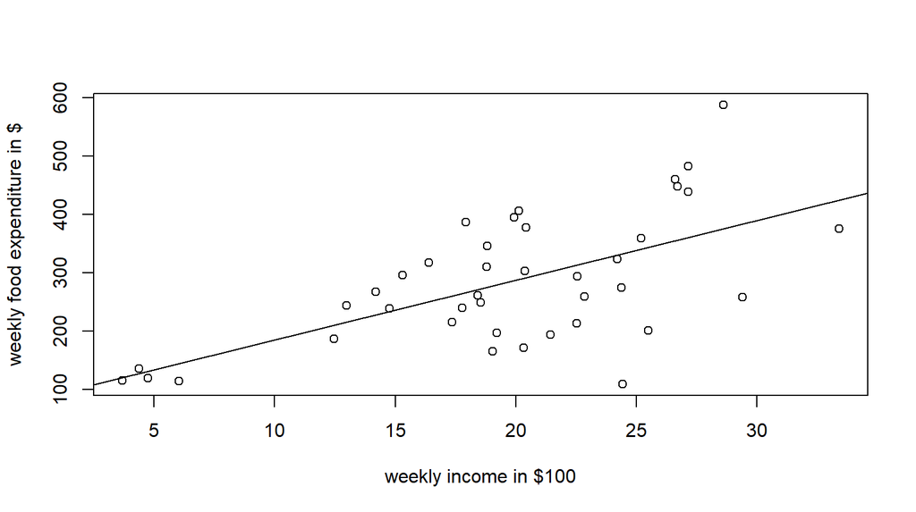

```r
b1 <- coef(mod1)[[1]]
b2 <- coef(mod1)[[2]]

plot(food$income, food$food_exp,
     xlab="weekly income in $100",
     ylab="weekly food expenditure in $",
     type = "p")
abline(b1,b2)
```

## Prediction

## The `predict()` function

- `predict()` calculates the predicted value of the dependent variable
- It also the confidence and prediction intervals for that estimate.

You need to store the values of the independent variable to use in the predictions.  
`new.data <- data.frame("income" = 20)`

## The `predict()` function

```r
predict(mod1, newdata=new.data, interval="confidence", level=0.95)
```

| fit | lwr | upr |
| --- | --- | --- |
| 287.6089 | 258.9069 | 316.3108 |

```r
predict(mod1, newdata=new.data, interval="predict", level=0.95)
```

| fit | lwr | upr |
| --- | --- | --- |
| 287.6089 | 104.1323 | 471.0854 |

## Prediction Probability

## Probability of a range of outcomes

- It can be quite useful to determine the probability of a range of events rather than a single value.
- For example, we might want to predict the probability that a household with an income of 20 will spend at least $200 dollars per week on food.

## Some theory

- The estimate of \(y\), i.e. \(\hat{y}\), is a random variable with a student’s t distribution.
- we can use `pt()` to estimate the probably of an actual realization of \(y\) being within a given range.
- We first need to calculate a \(t-stat\)

\[t-stat = \frac{value - \hat{y}}{ standard\ error\ of\ prediction }\]

- Unfortunately, R dose not provide an easy way to access the standard error of prediction.
- So I have written two functions `predict.prob ()` and `predict.plot ()` to make this procedure easier.

## Prediction Functions

```r
predict.prob <- function(lmod,
                      new.data,
                      alpha=0.05,
                      alternative="greater",
                      value)
  {
    prediction <- predict(lmod,
                          newdata = new.data,
                          interval="predict",
                          level =1-alpha,
                          se.fit = T)
    cv <- qt(p=alpha/2, df = prediction$df, lower.tail = FALSE)
    se <- (prediction$fit[,"upr"] - prediction$fit[,"fit"])/cv
    t.stat <- (value-prediction$fit[,"fit"])/se
    ret = data.frame("value"=value,
                     "prob"=pt(q=t.stat,
                            df=prediction$df,
                            lower.tail = (alternative=="less")),
                     "alternative"=alternative,
                     "fit"=prediction$fit[,"fit"],
                     "upr"=prediction$fit[,"upr"],
                     "lwr"=prediction$fit[,"lwr"],
                     "df" = prediction$df,
                     "cv" = cv,
                     "se" = se,
                     "t.stat" = t.stat
                     )
    return(ret)
}


predict.plot <- function(prediction){
  x=seq(-4,4,length=400)
  y=dt(x, df=prediction$df)
  t = ifelse((prediction$alternative=="less"),-1,1)
  x1=seq(t*4,prediction$t.stat,length=400)
  y1=dt(x1, df=prediction$df)
  plot(x,y,type="l", lwd=2, col="black")
  polygon(c(4,prediction$t.stat,x1),c(0,y1,0),col="gray")
  abline(v=0)
}
```

## Calculate the probability

Here we will predict the probability that a household with an income of 20 will spend at least $200 dollars per week on food.

```r
mod1.prod <- predict.prob(mod1,
              new.data = data.frame("income"=20),
              alpha = 0.05,
              alternative <- "greater",
              value <- 200)

kable(mod1.prod, digits = 3, align = "l")
```

| value | prob | alternative | fit | upr | lwr | df | cv | se | t.stat |
| --- | --- | --- | --- | --- | --- | --- | --- | --- | --- |
| 200 | 0.83 | greater | 287.609 | 471.085 | 104.132 | 38 | 2.024 | 90.633 | -0.967 |

## Visualize the prediction probability

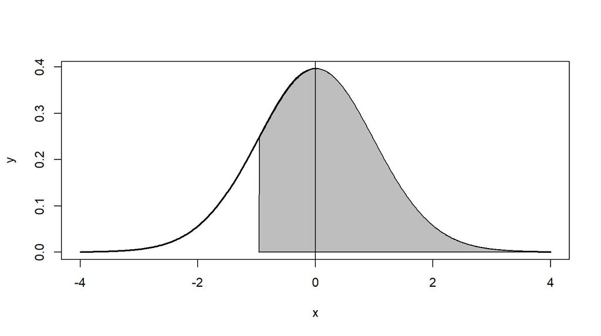

```r
predict.plot(mod1.prod)
```

The horizontal axis is measured in the same scale as the \(t-score\), thus the zero corresponds to the predicted value of \(y\), and the shading corresponds to the prediction range.

## You did it!